# 12. 상관관계_회귀분석

```r
x <- c(0,1,4,9,16)
# 평균
mean(x)
y <- c(1,2,3,4)
z <- c(0,5,7,9)
#y와 z의 피어슨 상관계수
cor(y, z, method = "pearson")
#y와 z의 스피어맨 상관계수
cor(y, z, method = "spearman")
```

6

0.96936309217407

1

```r
y <- c(1,2,3,4)
z <- c(9,10,5,100)
#y와 z의 피어슨 상관계수
cor(y, z, method = "pearson")
#y와 z의 스피어맨 상관계수
cor(y, z, method = "spearman")
```

0.751316564233693

0.4

상관 분석 담배값 인상이 흡연이 미치는 미치는 영향을 분석. 귀무가설 : 담배값 인상과 흡연과는 관련이 없다. 대립가설 : 담배값 인상과 흡연과는 관련이 있다.

```r
# 피어슨 상관 분석
x <- c(70,72,62,64,71,76,0,65,74,72)
y <- c(70,74,65,68,72,74,61,66,76,75)
cor.test(x,y, method = "pearson")
```

```
	Pearson's product-moment correlation

data:  x and y
t = 3.4455, df = 8, p-value = 0.008752
alternative hypothesis: true correlation is not equal to 0
95 percent confidence interval:
 0.2791495 0.9434286
sample estimates:
      cor
0.7729264
```

```r
# ** p-value = 0.008752 < 0.05 이므로 대립가설을 채택한다.
# cor = 0.7729264 이므로 약 77%의 상관 관계가 발생한다.
# 결정계수가 0.7 ~ 1.0 : 강한 양적 선형 관계
```

단순회귀 분석

```r
#csv file 불러오기
regression <- read.csv("../Data/regression.csv")
# 데이터의 처음부분과 끝부분 보기
head(regression)
tail(regression)
```

| age | Height | Weight |
| --- | --- | --- |
| 0~3Months | 59.1 | 5.9 |
| 3~6Months | 66.7 | 8.0 |
| 6~9Months | 71.4 | 8.9 |
| 9~12Months | 75.0 | 10.1 |
| 12~18Months | 80.1 | 10.9 |
| 2Year | 87.8 | 13.2 |

|  | age | Height | Weight |
| --- | --- | --- | --- |
| 26 | 30~34Year | 171.3 | 71.5 |
| 27 | 35~39Year | 170.7 | 72.3 |
| 28 | 40~49Year | 168.6 | 70.6 |
| 29 | 50~59Year | 166.1 | 69.1 |
| 30 | 60~69Year | 164.4 | 65.9 |
| 31 | 70YearOver | 162.4 | 61.1 |

```r
# 기본 통계량 확인
summary(regression$Height)
summary(regression$Weight)
```

```
   Min. 1st Qu.  Median    Mean 3rd Qu.    Max.
   59.1   105.7   150.7   135.8   169.8   173.8
```

```
   Min. 1st Qu.  Median    Mean 3rd Qu.    Max.
   5.90   17.90   45.20   42.62   66.65   72.30
```

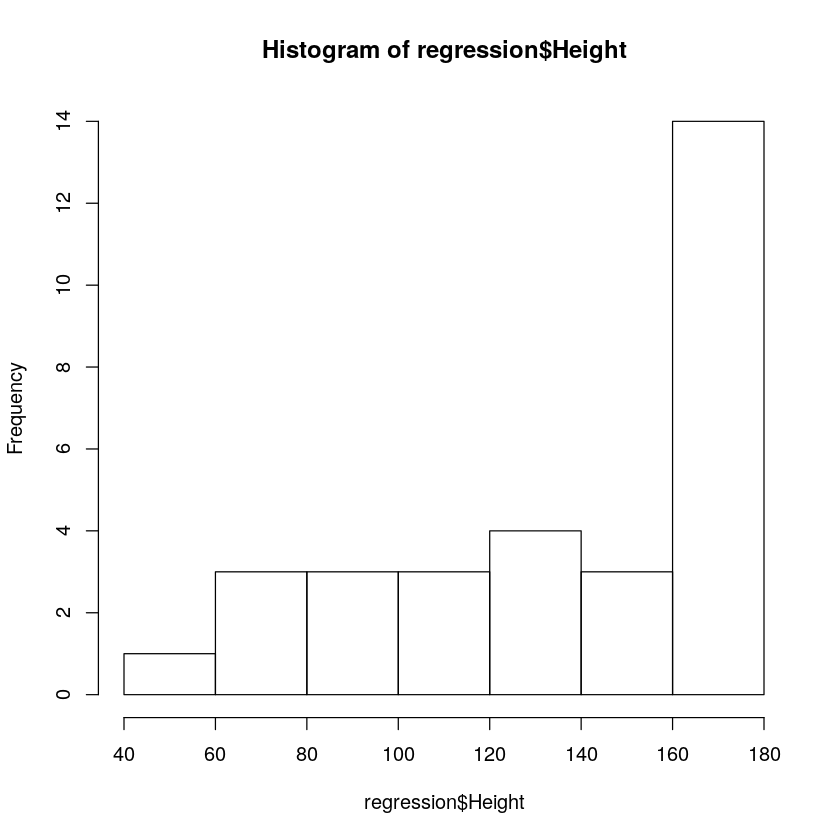

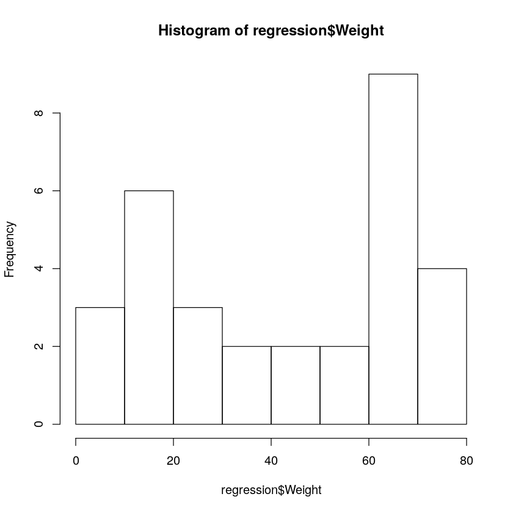

```r
#히스토그램
hist(regression$Height)
hist(regression$Weight)
```

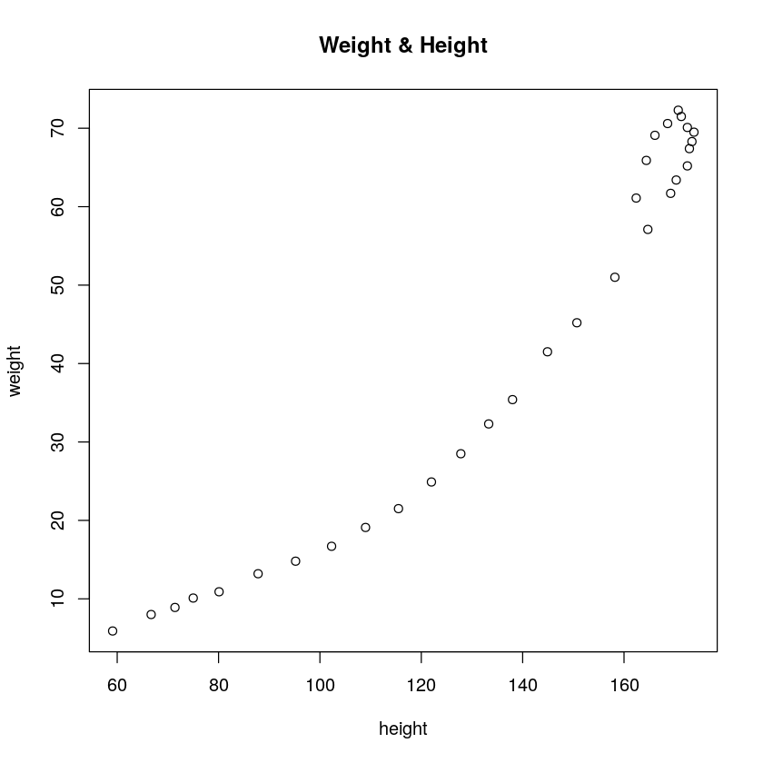

```r
# 산점도 그래프
plot(regression$Weight ~ regression$Height,
     main = "Weight & Height", xlab="height", ylab="weight")
```

```r
# 상관계수 구하기
cor(regression$Height, regression$Weight)
```

0.967210305922711

회귀분석(사용하고자 하는 데이터셋이 연속적인 숫자로 구성되어야 사용가능함).  
독립변수 : 키.  
종속변수 : 몸무게.  
귀무가설 : 키는 몸무게에 영향을 주지 않는다.  
대립가설 : 키는 몸무게에 영향을 준다.  
lm(y ~ x) : x(독립변수), y(종속변수)

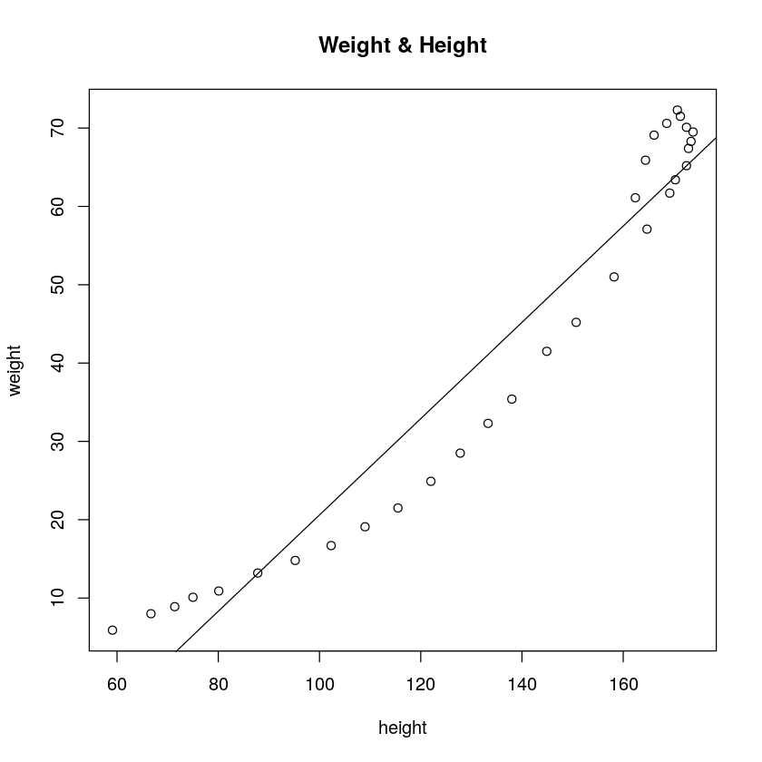

```r
plot(regression$Weight ~ regression$Height,
     main = "Weight & Height", xlab="height", ylab="weight")
# 회귀분석
r <- lm(regression$Weight ~ regression$Height)
# 회귀선 그리기
abline(r) # plot이 있는 상태에서 회귀선을 그려야 함으로 plot 함수와 같이 있어야 한다.
```

```r
# 분석결과
summary(r)
```

```
Call:
lm(formula = regression$Weight ~ regression$Height)

Residuals:
    Min      1Q  Median      3Q     Max
-9.2327 -5.9811  0.0915  5.3125 10.4346

Coefficients:
                   Estimate Std. Error t value Pr(>|t|)
(Intercept)       -40.86594    4.22768  -9.666 1.42e-10 ***
regression$Height   0.61474    0.02998  20.508  < 2e-16 ***
---
Signif. codes:  0 ‘***’ 0.001 ‘**’ 0.01 ‘*’ 0.05 ‘.’ 0.1 ‘ ’ 1

Residual standard error: 6.355 on 29 degrees of freedom
Multiple R-squared:  0.9355,	Adjusted R-squared:  0.9333
F-statistic: 420.6 on 1 and 29 DF,  p-value: < 2.2e-16
```

Adjusted R-squared: 0.9333 --> 93%의 예측력을 가진다. p-value: < 2.2e-16 : 0.05보다 작으므로 대립가설을 채택한다. *** 키와 몸무게는 유의미한 관계가 있다.

```r
r # 회귀식 구성
```

```
Call:
lm(formula = regression$Weight ~ regression$Height)

Coefficients:
      (Intercept)  regression$Height
         -40.8659             0.6147
```

y = 0.6147 * regression$Height + (-40.8659)

```r
# IQ Test
s <- read.csv("../Data/iq.csv")
```

```r
s
```

| 이름 | 성적 | IQ | 다니는.학원수 | 게임하는.시간 | TV시청.시간 |
| --- | --- | --- | --- | --- | --- |
| A | 90 | 140 | 2 | 1 | 0 |
| B | 75 | 125 | 1 | 3 | 3 |
| C | 77 | 120 | 1 | 0 | 4 |
| D | 83 | 135 | 2 | 3 | 2 |
| E | 65 | 105 | 0 | 4 | 4 |
| F | 80 | 123 | 3 | 1 | 1 |
| G | 83 | 132 | 3 | 4 | 1 |
| H | 70 | 115 | 1 | 1 | 3 |
| I | 87 | 128 | 4 | 0 | 0 |
| J | 79 | 131 | 2 | 2 | 3 |

(1) IQ가 126인 사람의 성적을 예측해 보시오.  
(2) 성적과 가장 관련이 깊은 항목은 ?  
(3) 학원을 몇군데 다녀야 성적이 90점 이상이 될까?  
(4) 성적이 85점이상이려면 IQ는 얼마이상 ?

```r
lm1 <- lm(s$성적 ~ s$IQ)
lm1
```

```
Call:
lm(formula = s$성적 ~ s$IQ)

Coefficients:
(Intercept)         s$IQ
    -5.2918       0.6714
```

y = 0.6714 * IQ + (-5.2918)

```r
# 다중회귀 분석
# 장 데이터셋을 확인
data()
```

```r
# attitude data 사용, head와 tail로 확인
?attitude # attitude dataset의 구성을 확인
head(attitude)
tail(attitude)
```

| rating | complaints | privileges | learning | raises | critical | advance |
| --- | --- | --- | --- | --- | --- | --- |
| 43 | 51 | 30 | 39 | 61 | 92 | 45 |
| 63 | 64 | 51 | 54 | 63 | 73 | 47 |
| 71 | 70 | 68 | 69 | 76 | 86 | 48 |
| 61 | 63 | 45 | 47 | 54 | 84 | 35 |
| 81 | 78 | 56 | 66 | 71 | 83 | 47 |
| 43 | 55 | 49 | 44 | 54 | 49 | 34 |

|  | rating | complaints | privileges | learning | raises | critical | advance |
| --- | --- | --- | --- | --- | --- | --- | --- |
| 25 | 63 | 54 | 42 | 48 | 66 | 75 | 33 |
| 26 | 66 | 77 | 66 | 63 | 88 | 76 | 72 |
| 27 | 78 | 75 | 58 | 74 | 80 | 78 | 49 |
| 28 | 48 | 57 | 44 | 45 | 51 | 83 | 38 |
| 29 | 85 | 85 | 71 | 71 | 77 | 74 | 55 |
| 30 | 82 | 82 | 39 | 59 | 64 | 78 | 39 |

```r
# rating을 제외한 변수들이 rating에 어떤 영향을 미치는지 회귀분석
# lm(종속변수, . , data = 데이터셋)
model <- lm(rating ~ .,data=attitude)
#model <- lm(rating ~ complaints + privileges + learning + raises + critical + advance, data = attitude)
model
```

```
Call:
lm(formula = rating ~ ., data = attitude)

Coefficients:
(Intercept)   complaints   privileges     learning       raises     critical
   10.78708      0.61319     -0.07305      0.32033      0.08173      0.03838
    advance
   -0.21706
```

```r
# 회귀모델 요약
summary(model)
```

```
Call:
lm(formula = rating ~ ., data = attitude)

Residuals:
     Min       1Q   Median       3Q      Max
-10.9418  -4.3555   0.3158   5.5425  11.5990

Coefficients:
            Estimate Std. Error t value Pr(>|t|)
(Intercept) 10.78708   11.58926   0.931 0.361634
complaints   0.61319    0.16098   3.809 0.000903 ***
privileges  -0.07305    0.13572  -0.538 0.595594
learning     0.32033    0.16852   1.901 0.069925 .
raises       0.08173    0.22148   0.369 0.715480
critical     0.03838    0.14700   0.261 0.796334
advance     -0.21706    0.17821  -1.218 0.235577
---
Signif. codes:  0 ‘***’ 0.001 ‘**’ 0.01 ‘*’ 0.05 ‘.’ 0.1 ‘ ’ 1

Residual standard error: 7.068 on 23 degrees of freedom
Multiple R-squared:  0.7326,	Adjusted R-squared:  0.6628
F-statistic:  10.5 on 6 and 23 DF,  p-value: 1.24e-05
```

"complaints ***", "learning . "인 변수가 ranking에 영향을 많이 주므로 중요하다 Adjusted R-squared: 0.6628(예측력 66%) p-value: 1.24e-05 : 0.05보다 작으므로 95%신뢰수준하에서 이 모델은 유의

```r
# 예측력을 높이기 위해서 상대적으로 기여도가 낮은 변수를 제거
reduced <- step(model, direction="backward")
```

```
Start:  AIC=123.36
rating ~ complaints + privileges + learning + raises + critical +
    advance

             Df Sum of Sq    RSS    AIC
- critical    1      3.41 1152.4 121.45
- raises      1      6.80 1155.8 121.54
- privileges  1     14.47 1163.5 121.74
- advance     1     74.11 1223.1 123.24
<none>                    1149.0 123.36
- learning    1    180.50 1329.5 125.74
- complaints  1    724.80 1873.8 136.04

Step:  AIC=121.45
rating ~ complaints + privileges + learning + raises + advance

             Df Sum of Sq    RSS    AIC
- raises      1     10.61 1163.0 119.73
- privileges  1     14.16 1166.6 119.82
- advance     1     71.27 1223.7 121.25
<none>                    1152.4 121.45
- learning    1    177.74 1330.1 123.75
- complaints  1    724.70 1877.1 134.09

Step:  AIC=119.73
rating ~ complaints + privileges + learning + advance

             Df Sum of Sq    RSS    AIC
- privileges  1     16.10 1179.1 118.14
- advance     1     61.60 1224.6 119.28
<none>                    1163.0 119.73
- learning    1    197.03 1360.0 122.42
- complaints  1   1165.94 2328.9 138.56

Step:  AIC=118.14
rating ~ complaints + learning + advance

             Df Sum of Sq    RSS    AIC
- advance     1     75.54 1254.7 118.00
<none>                    1179.1 118.14
- learning    1    186.12 1365.2 120.54
- complaints  1   1259.91 2439.0 137.94

Step:  AIC=118
rating ~ complaints + learning

             Df Sum of Sq    RSS    AIC
<none>                    1254.7 118.00
- learning    1    114.73 1369.4 118.63
- complaints  1   1370.91 2625.6 138.16
```

첫번째 단계를 보면 critical이 3.41로 기여도가 제일 낮아서 두번째 단계시에는 제거하고 진행 두번째 단계를 보면 raises가 10.61 " 세번째 " 세번쩨 " privileges가 16.10 " 네번쩨 " 네번째 " advance가 75.54 " 제외하고 다섯번째 단계에서는 complaints + learning 만으로 회귀분석을 실행

```r
# 요약
summary(reduced)
```

```
Call:
lm(formula = rating ~ complaints + learning, data = attitude)

Residuals:
     Min       1Q   Median       3Q      Max
-11.5568  -5.7331   0.6701   6.5341  10.3610

Coefficients:
            Estimate Std. Error t value Pr(>|t|)
(Intercept)   9.8709     7.0612   1.398    0.174
complaints    0.6435     0.1185   5.432 9.57e-06 ***
learning      0.2112     0.1344   1.571    0.128
---
Signif. codes:  0 ‘***’ 0.001 ‘**’ 0.01 ‘*’ 0.05 ‘.’ 0.1 ‘ ’ 1

Residual standard error: 6.817 on 27 degrees of freedom
Multiple R-squared:  0.708,	Adjusted R-squared:  0.6864
F-statistic: 32.74 on 2 and 27 DF,  p-value: 6.058e-08
```

Adjusted R-squared: 0.6864 가 약간은 개선된다.